# Solution to Exercise 7.7

### 02409 Multivariate Statistics

`Week D`

We consider the data given in Exercise 7.1. where we exclude the variable ‘points’.

```r
Heptathlon = data.frame("Name" = c("Joyner_Kersee,(USA)","John,(GDR)","Behmer,(GDR)","Choubenkova,(URS)","Sablovskaite,(URS)","Schulz,(GDR)","Fleming,(AUS)","Greiner,(USA)","Lajbnerova,(CZE)","Bouraga,(URS)","Wijnsma,(HOL)","Dimitrova,(BUL)","Scheider,(SWI)","Braun,(FRG)","Ruotsalainen,(FIN)","Yuping,(CHN)","Hagger,(GB)","Brown,(USA)","Mulliner,(GB)","Hautenauve,(BEL)","Kytola,(FIN)","Geremias,(BRA)","Hui-Ing,(TAI)","Jeong-Mi,(KOR)","Launa,(PNG)"),
                      "Points"= c(7291,6897,6858,6540,6456,6411,6351,6297,6252,6232,6205,6171,6157,6109,6101,6087,5975,5972,5746,5734,5686,5508,5290,5289,4566),
                      "Hurdles" = c(12.69,12.85,13.20,13.51,13.61,13.75,13.38,13.55,13.63,13.25,13.75,13.24,13.85,13.71,13.79,13.93,13.47,14.07,14.39,14.04,14.31,14.23,14.85,14.53,16.42),
                      "High Jump"=c(1.86,1.80,1.83,1.74,1.80,1.83,1.80,1.80,1.83,1.77,1.86,1.80,1.86,1.83,1.80,1.86,1.80,1.83,1.71,1.77,1.77,1.71,1.68,1.71,1.50),
                       "Shot" = c(15.80,16.23,14.20,14.76,15.23,13.50,12.88,14.13,14.28,12.62,13.01,12.02,11.58,13.16,12.32,14.21,12.75,12.69,12.68,11.81,11.66,12.95,10.00,10.83,11.78),
                       "Run200" = c(22.56,23.65,23.10,23.93,23.92,24.65,23.59,24.48,24.86,23.59,25.03,23.59,24.87,24.78,24.61,25.00,25.47,24.83,24.92,25.61,25.69,25.50,25.23,26.61,26.16),
                       "Longjump" = c(7.27,6.71,6.68,6.32,6.25,6.33,6.37,6.47,6.11,6.28,6.34,6.19,6.05,6.12,6.08,6.40,6.34,6.13,6.10,5.99,5.75,5.50,5.47,5.50,4.88),
                       "Javelin" = c(45.66,42.56,44.54,47.46,42.78,42.82,40.28,38.00,43.30,39.06,37.86,37.62,47.50,44.58,45.44,38.60,35.78,44.34,37.76,35.68,39.48,39.64,39.14,39.26,46.38),
                       "Run800" = c(128.51,126.14,124.20,127.90,132.24,125.79,132.54,133.65,136.05,134.74,131.49,135.73,134.93,142.82,137.06,146.67,138.48,146.43,138.02,133.90,133.35,144.02,137.30,139.17,163.43))
```

**1. Make a factor analysis with n=2 factors and rotate the factors by means of the Varimax criterion.**

```r
Hep <-Heptathlon[,-c(1,2)]
Eigs <- eigen(cor(Hep))

var <- Eigs$values
varProp <- var/sum(var)
cumu = rep(NA,length(var))
for (i in 1:length(var)){
  cumu[i] = sum(varProp[1:i])
}
results <- data.frame("eigenvalues"=var,"proportion"=varProp,
                      "cumulative" = cumu)
print("Eigenvalues of the Correlation Matrix:")
results
```

```
## [1] "Eigenvalues of the Correlation Matrix:"
```

```
##   eigenvalues proportion cumulative
## 1  4.41699433 0.63099919  0.6309992
## 2  1.19602462 0.17086066  0.8018599
## 3  0.51002343 0.07286049  0.8747203
## 4  0.45861676 0.06551668  0.9402370
## 5  0.28957437 0.04136777  0.9816048
## 6  0.07902477 0.01128925  0.9928940
## 7  0.04974172 0.00710596  1.0000000
```

```r
#### Factor analysis 2 Factors ####
#unrotated factors
fa <- principal(cor(Hep),nfactors = 2,rotate = "none")
fal <- fa$loadings[,1:2]
facom <- fa$communality

#rotated factors:
rfa <-principal(cor(Hep),nfactors = 2,rotate = "varimax",scores = T)
rfal <- rfa$loadings[,1:2]
rfacom <- rfa$communality

# The 1st Factor is correct as it comes directly from pca's Evals and Evecs, but rotation...?
Factors <- data.frame("FA" = fal,"Rot_FA" = rfal)
print("Non rotated and rotated factors:")
Factors

#Communality:
Commu <- data.frame("comun" = facom, "rot_comun" = rfacom)
print("Final Communality Estimates (non rotated and rotated):")
Commu

#Variance explained:
var <- c(sum(fal[,1]^2),sum(fal[,2]^2))
# var can also be found with fa$values[1:2], but not available for rotated factors
rvar <- c(sum(rfal[,1]^2),sum(rfal[,2]^2))
Var <- data.frame("var" = var,"rot_var" = rvar)
print("Variance Explained by Each Factor:")
Var
```

```
## [1] "Non rotated and rotated factors:"
```

```
##               FA.PC1      FA.PC2  Rot_FA.RC1  Rot_FA.RC2
## Hurdles   -0.9527330  0.18394262  0.96904538 -0.04986118
## High.Jump  0.7998971 -0.25979027 -0.83885384 -0.06041963
## Shot       0.7550672  0.36064144 -0.64656995  0.53116479
## Run200    -0.8516293 -0.24433641  0.76820184 -0.44140527
## Longjump   0.9626588 -0.05003306 -0.94657391  0.18224443
## Javelin    0.1500479  0.91996733  0.07491091  0.92910851
## Run800    -0.7904642  0.23683966  0.82419326  0.04040023
```

```
## [1] "Final Communality Estimates (non rotated and rotated):"
```

```
##               comun rot_comun
## Hurdles   0.9415351 0.9415351
## High.Jump 0.7073263 0.7073263
## Shot      0.7001887 0.7001887
## Run200    0.7849727 0.7849727
## Longjump  0.9292152 0.9292152
## Javelin   0.8688543 0.8688543
## Run800    0.6809267 0.6809267
```

```
## [1] "Variance Explained by Each Factor:"
```

```
##        var  rot_var
## 1 4.416994 4.231820
## 2 1.196025 1.381199
```

**2. What characterizes an athlete with a high score of factor 1 and of factor 2? Are there big differences between the interpretation of the unrotated and the rotated factors?**

A high value of rotated factor 1 means that the running times in hurdles, 200 meters and 800 meters are very large, i.e. the athlete is slow, combined with low values of highjump, longjump and shot, again an indication of a not so good athlete. A high value of rotated factor 2 corresponds to high values in javelin and shot (and to a lesser extent low 200 meters running time long longjumps), i.e. we have an athlete not bad at running and jumping who is very good in javelin and shot. The major difference between the rotated and unrotated analysis is a change of sign. This is also confirmed by the factor patterns depicted below.

**3. What is the fraction of the total variation described by each of the 2 unrotated and the 2 rotated factors, and what is the fraction described by the 2 factors combined in both cases?**

```r
sum(1/7*Var[,1])*100
sum(1/7*Var[,2])*100
```

```
## [1] 80.18599
```

```
## [1] 80.18599
```

The fractions are:

$\frac{1}{7} \times 4.4170 = 63.1\%$ & $\frac{1}{7} \times 1.1960 = 17.1\%$

$\frac{1}{7} \times 4.2318 = 60.5\%$ & $\frac{1}{7} \times 1.3812 = 19.7\%$

and:

$63.1\% + 17.1\% = 60.5\% + 19.7\% = 80.2\% = \frac{1}{7} \times 5.6130$

**4. For the variable ‘hurdles’, the factor pattern values are $[-0.95273, 0.18394]$ in the unrotated and $[0.96905, -0.04985]$ in the rotated case. Determine the 2 sums of squares $(-0.95273)^2 + 0.18394^2$ and $0.96905^2 + (-0.04985)^2$. How may those quantities be interpreted?**

```r
Factors$FA.PC1[1]^2+Factors$FA.PC2[1]^2
Factors$Rot_FA.RC1[1]^2+Factors$Rot_FA.RC2[1]^2
```

```
## [1] 0.9415351
```

```
## [1] 0.9415351
```

$(-0.95273)^2 + 0.18394^2 = 0.96905^2 + (-0.04986)^2 = 0.9415$

the communality for ‘hurdles’, i.e. the part of the variation in ‘hurdles’ that is explained by the 2 unrotated or the 2 rotated factors.

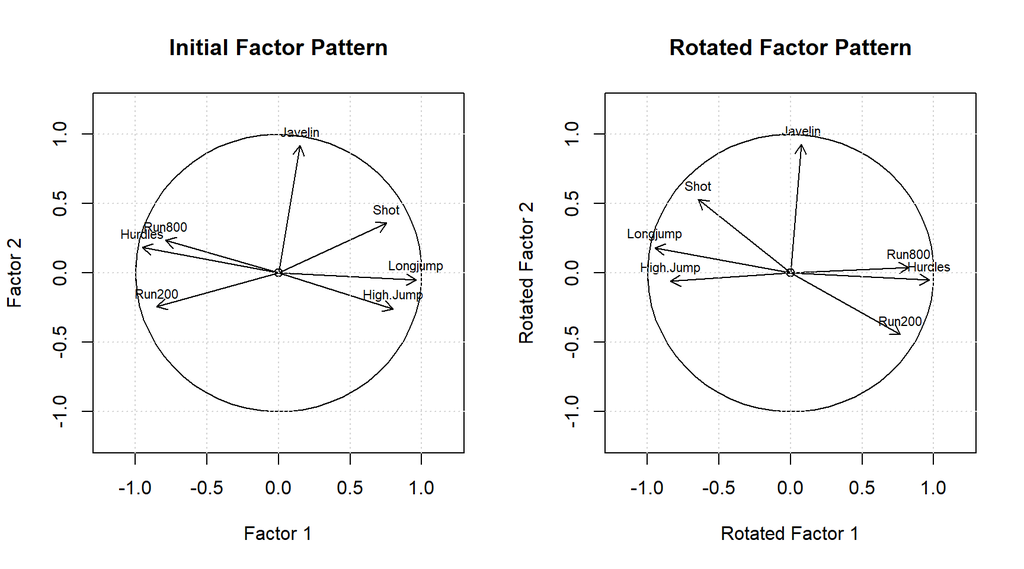

```r
# Plots for 2-factor analysis:

par(mfrow=c(1,2))
circle = seq(-3.2,3.2,by=0.1)

#Plot for Factors 1&2
plot(0,0,xlim = c(-1.2,1.2),ylim = c(-1.2,1.2),xlab = "Factor 1",
     ylab = "Factor 2",main = "Initial Factor Pattern")
points(1*cos(circle),1*sin(circle),type='l')
arrows(c(rep(0,7)),c(rep(0,7)),fal[,1],fal[,2],length = 0.1)
text(fal[,1],fal[,2]+0.1,names(Hep),cex = 0.7)
grid()

#Plot for rotated Factors 1&2
plot(0,0,xlim = c(-1.2,1.2),ylim = c(-1.2,1.2),xlab = "Rotated Factor 1",
     ylab = "Rotated Factor 2",main = "Rotated Factor Pattern")
points(1*cos(circle),1*sin(circle),type='l')
arrows(c(rep(0,7)),c(rep(0,7)),rfal[,1],rfal[,2],length = 0.1)
text(rfal[,1],rfal[,2]+0.1,names(Hep),cex = 0.7)
grid()
```

*Now perform a factor analysis with n=3 factors*

```r
#### Factor analysis 3 Factors ####
fa3 <- principal(cor(Hep),nfactors = 3,rotate = "none")
fa3l <- fa3$loadings[,1:3]
fa3com <- fa3$communality

#rotated:
rfa3 <- principal(cor(Hep),nfactors = 3,rotate = "varimax")
rfa3l <- rfa3$loadings[,1:3]
rfa3com <- rfa3$communality

#Factors
Factors3 <- data.frame("FA" = fa3l,"Rot FA" = rfa3l)
print("Non rotated and rotated factors:")
Factors3

#Communality:
Commu3 <- data.frame("comun" = fa3com, "rot comun" = rfa3com)
print("Final Communality Estimates (non rotated and rotated):")
Commu3

#Variance explained:
rvar3 = c(sum(rfa3l[,1]^2),sum(rfa3l[,2]^2),sum(rfa3l[,3]^2))
var3 <- c(sum(fa3l[,1]^2),sum(fa3l[,2]^2),sum(fa3l[,3]^2))
Var3 <- data.frame("var" = var3[1:3],"rotvar" = rvar3)
print("Variance Explained by Each Factor:")
Var3
```

```
## [1] "Non rotated and rotated factors:"
```

```
##               FA.PC1      FA.PC2      FA.PC3  Rot.FA.RC1 Rot.FA.RC3
## Hurdles   -0.9527330  0.18394262  0.02701241  0.82655571 -0.5052596
## High.Jump  0.7998971 -0.25979027 -0.29669430 -0.87049868  0.1936952
## Shot       0.7550672  0.36064144  0.45730099 -0.22871051  0.9127234
## Run200    -0.8516293 -0.24433641 -0.09159858  0.53100113 -0.6728352
## Longjump   0.9626588 -0.05003306  0.10251349 -0.72010253  0.6489285
## Javelin    0.1500479  0.91996733 -0.35422467  0.04077065  0.1534899
## Run800    -0.7904642  0.23683966  0.26032215  0.83640249 -0.2215291
##             Rot.FA.RC2
## Hurdles    0.061507703
## High.Jump -0.008247107
## Shot       0.154726762
## Run200    -0.242267458
## Longjump  -0.008270361
## Javelin    0.984432817
## Run800     0.007076705
```

```
## [1] "Final Communality Estimates (non rotated and rotated):"
```

```
##               comun rot.comun
## Hurdles   0.9422648 0.9422648
## High.Jump 0.7953538 0.7953538
## Shot      0.9093129 0.9093129
## Run200    0.7933630 0.7933630
## Longjump  0.9397242 0.9397242
## Javelin   0.9943294 0.9943294
## Run800    0.7486943 0.7486943
```

```
## [1] "Variance Explained by Each Factor:"
```

```
##         var   rotvar
## 1 4.4169943 2.995012
## 2 1.1960246 2.072319
## 3 0.5100234 1.055712
```

```r
1/7*Var3[3,2]*100
sum(Factors3[,6]^2)
```

```
## [1] 15.08159
```

```
## [1] 1.055712
```

$\frac{1}{7} \times 1.055711 = 15.1\%$

$1.055711 = 0.061507^{2} +\ldots + 0.00708^{2}$

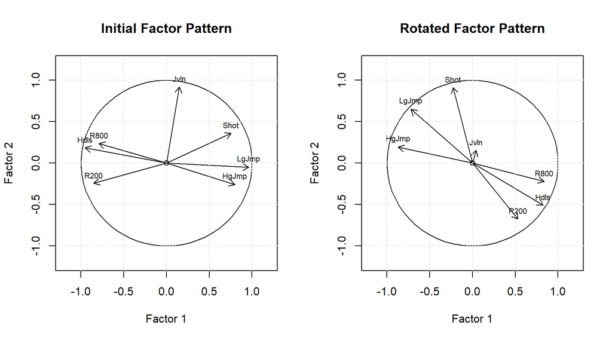

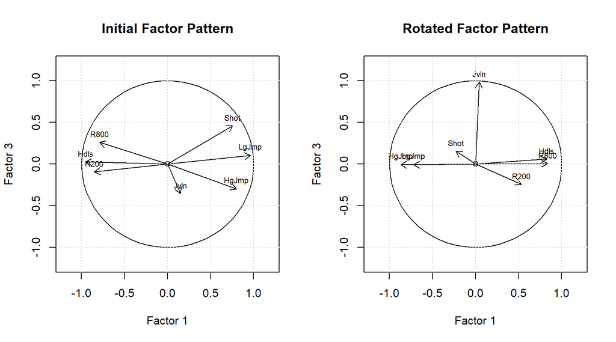

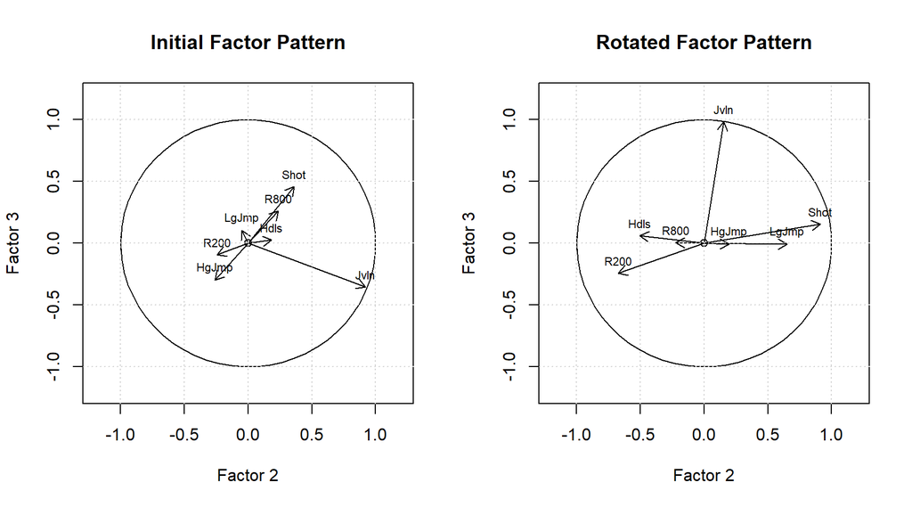

```r
# Plots for factor analysis with 3 factors:
par(mfrow = c(1,2))
circle = seq(-3.2,3.2,by=0.1)

# Different combinations of plots
ij = matrix(c(1,1,2,2,3,3),ncol=2)

Names = c("Hdls","HgJmp","Shot","R200","LgJmp","Jvln","R800")
for (i in 1:3){
  l = ij[i,1]
  k = ij[i,2]

  #Plot for the Factors
  plot(0,0,xlim = c(-1.2,1.2),ylim = c(-1.2,1.2),xlab = paste0("Factor ",l),
       ylab = paste0("Factor ",k),main = "Initial Factor Pattern")
  points(1*cos(circle),1*sin(circle),type='l')
  arrows(c(rep(0,7)),c(rep(0,7)),fa3l[,l],fa3l[,k],length = 0.1)
  text(fa3l[,l],fa3l[,k]+0.1,Names,cex = 0.7)
  grid()

  #Plot for rotated Factors
  plot(0,0,xlim = c(-1.2,1.2),ylim = c(-1.2,1.2),xlab = paste0("Factor ",l),
       ylab = paste0("Factor ",k),main = "Rotated Factor Pattern")
  points(1*cos(circle),1*sin(circle),type='l')
  arrows(c(rep(0,7)),c(rep(0,7)),rfa3l[,l],rfa3l[,k],length = 0.1)
  text(rfa3l[,l],rfa3l[,k]+0.1,Names,cex = 0.7)
  grid()
}
```

**6. Are there big differences between the interpretation of the unrotated and the rotated factors for n=3 factors?**

There are substantial differences between the unrotated and the rotated factor patterns. The most visible one is that rotated factor 3 is most strongly correlated with javelin and factor 2 with shot. Rotated factor 1 is more exclusively correlated with the running and jumping variables

**7. Determine the (factor1, factor2) score plot in the cases with 2 rotated and 3 rotated factors!**

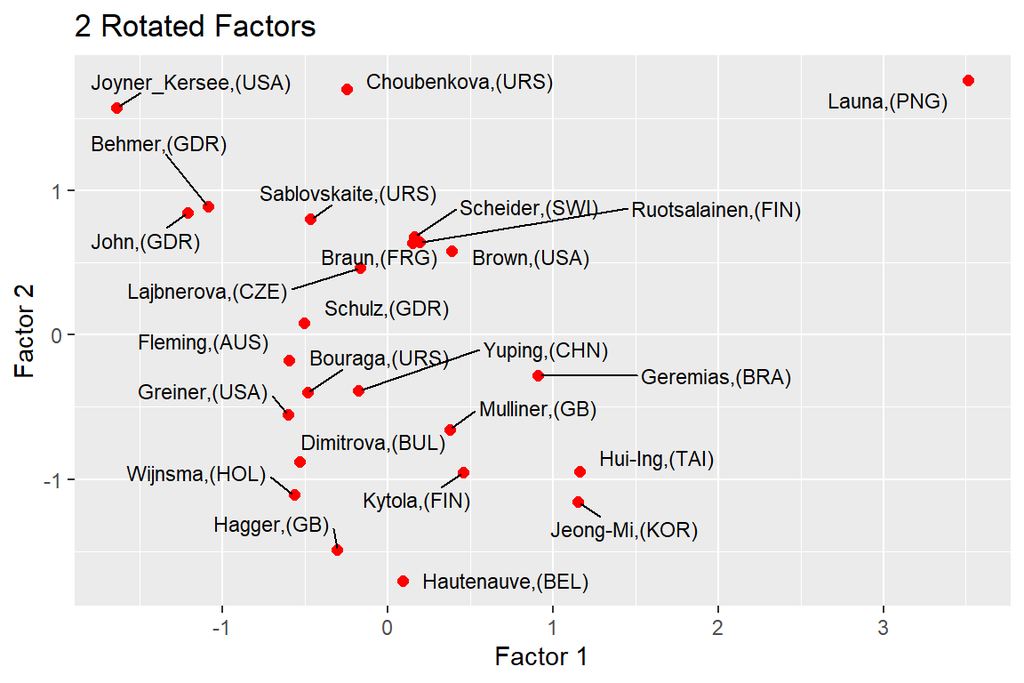

```r
competitors = Heptathlon$Name
#Scores plot for 2 Factors
F2 <- matrix(c(Factors[,3],Factors[,4]),ncol=2)

#Thurstone: regression based weights
ScoringF2 <- factor.scores(Hep,F2,method = "Thurstone")
Scoring_PointsF2 <- ScoringF2$scores

scores = data.frame(Scoring_PointsF2)
ggplot(scores,aes(x = scores[,1],y = scores[,2]))+
  geom_point(col = 'red',size = 2)+
  geom_text_repel(aes(label = competitors),box.padding = 0.5,cex=3,max.overlaps=100)+
  labs(x = 'Factor 1',y = 'Factor 2')+
  ggtitle('2 Rotated Factors')
```

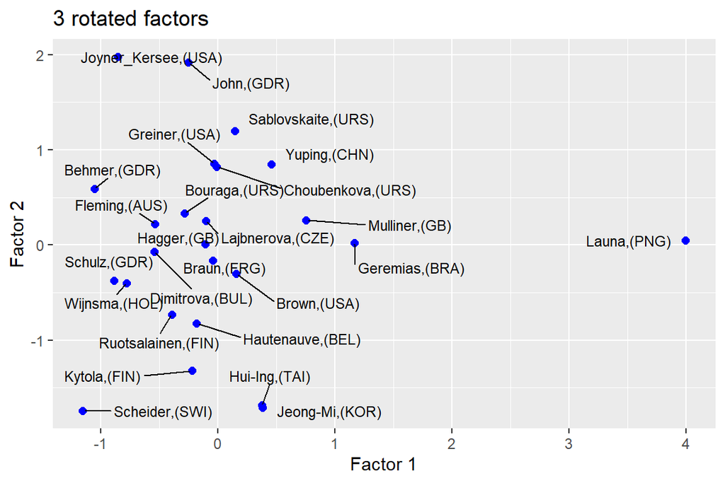

```r
#Scores plot for 3 Factors
F3 <- matrix(c(Factors3[,4],Factors3[,5],Factors3[,6]),ncol=3)

#Thurstone: regression based weights
ScoringF3 <- factor.scores(Hep,F3,method = "Thurstone")
Scoring_PointsF3 <- ScoringF3$scores

scores2 = data.frame(Scoring_PointsF3)

ggplot(scores2,aes(x = scores2[,1],y = scores2[,2]))+
  geom_point(col = 'blue',size = 2)+
  geom_text_repel(aes(label = competitors),box.padding = 0.5,cex=3,max.overlaps=100)+
  labs(x = 'Factor 1',y = 'Factor 2')+
  ggtitle('3 rotated factors')
```

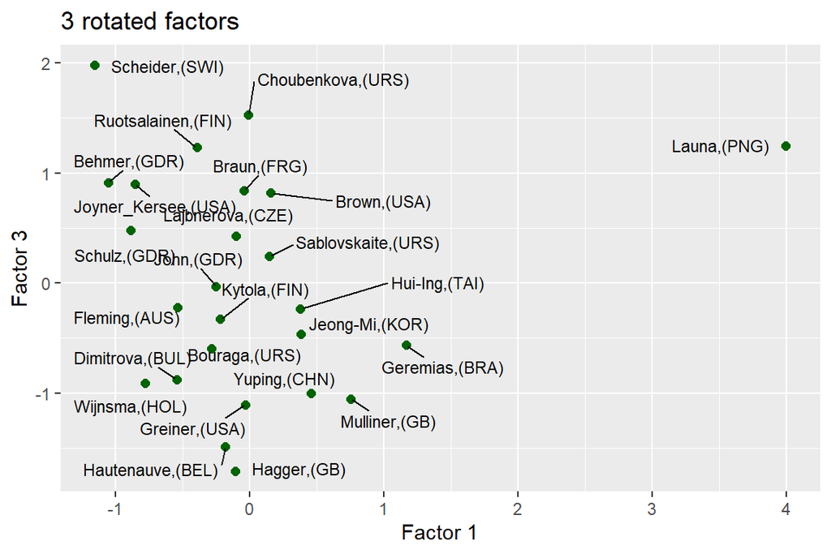

```r
ggplot(scores2,aes(x = scores2[,1],y = scores2[,3]))+
  geom_point(col = 'darkgreen',size = 2)+
  geom_text_repel(aes(label = competitors),box.padding = 0.5,cex=3,max.overlaps=100)+
  labs(x = 'Factor 1',y = 'Factor 3')+
  ggtitle('3 rotated factors')
```

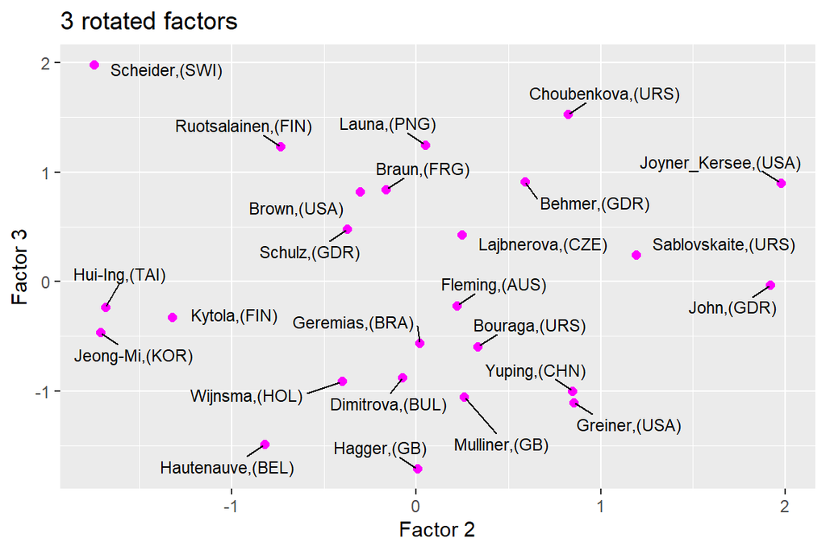

```r
ggplot(scores2,aes(x = scores2[,2],y = scores2[,3]))+
  geom_point(col = 'magenta',size = 2)+
  geom_text_repel(aes(label = competitors),box.padding = 0.5,cex=3,max.overlaps=100)+
  labs(x = 'Factor 2',y = 'Factor 3')+
  ggtitle('3 rotated factors')
```

**8. Relate the performance of different athletes to their positions in the factor score plots.**

The only discipline where Launa from Papua New Guinea (PNG) has a result in the better half is javelin where she actually is no 3 after Scheider and Choubenkova. On the other hand the gold medalist Joyner Kersee has results in almost all disciplines that are among the two or three best. These very different performances may be detected as differences in the position in the factor scores plots.